# Sensitivity analysis using fixed effects

The primary analyses presented in this manuscript pooled across individual studies using random effects. Inferences about estimates from fixed effects models are restricted to only the included studies.[^1] The random effects approach was more conservative in the presence of study heterogeneity, as evidenced by larger confidence intervals around each point estimates. Overall, the inference from results produced by each method was similar.

## Primary manuscript figures recreated with estimates pooled using fixed effects

More estimates are significant when pooling using fixed effects due to the generally smaller confidence intervals.

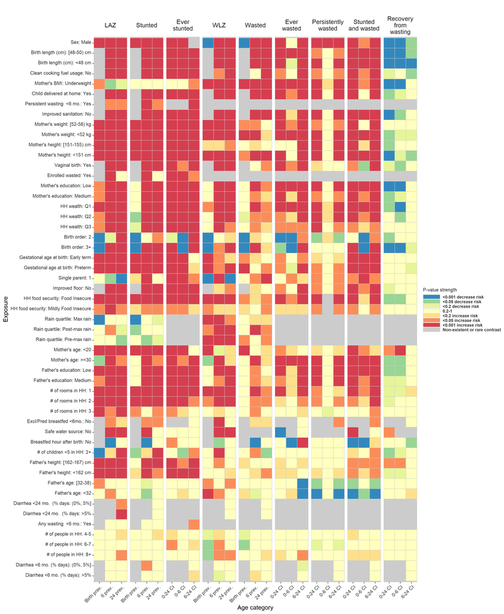

**Figure 1a. Heatmap of significance and direction across exposure-outcome combinations of associations estimated using fixed effects.**

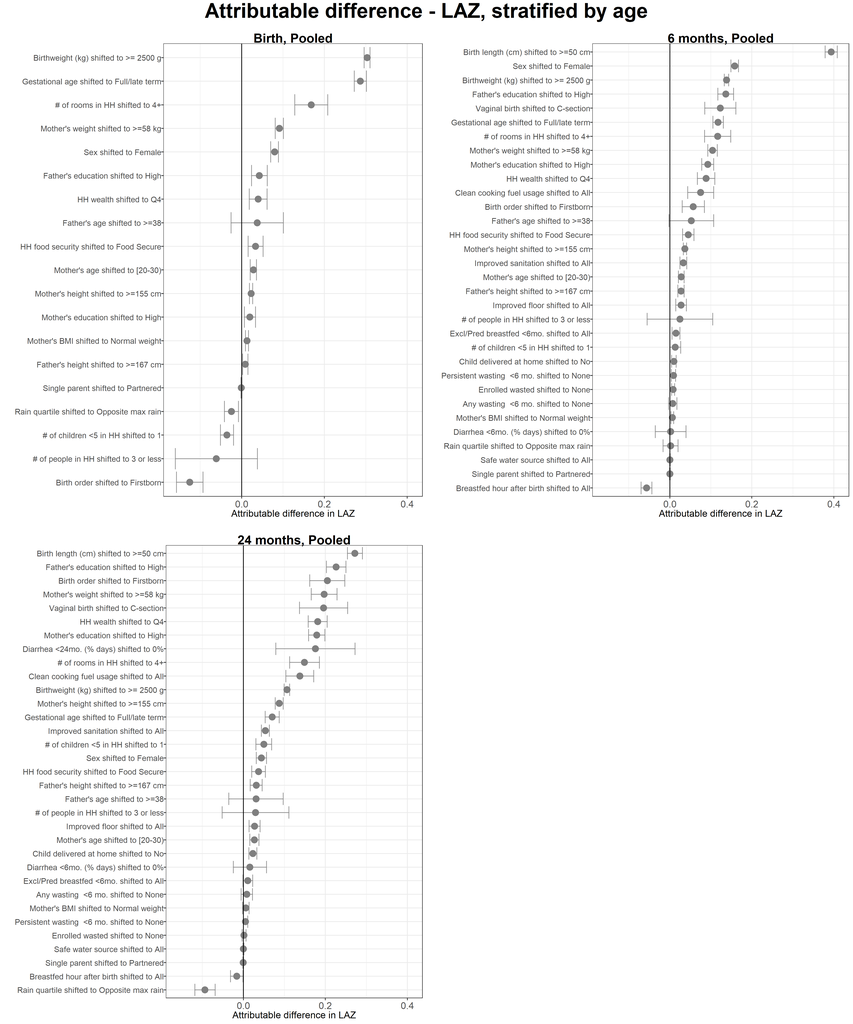

**Extended Data Figure 3 | Age-stratified population attributable differences in length-for-age Z-scores estimated using fixed effects.**

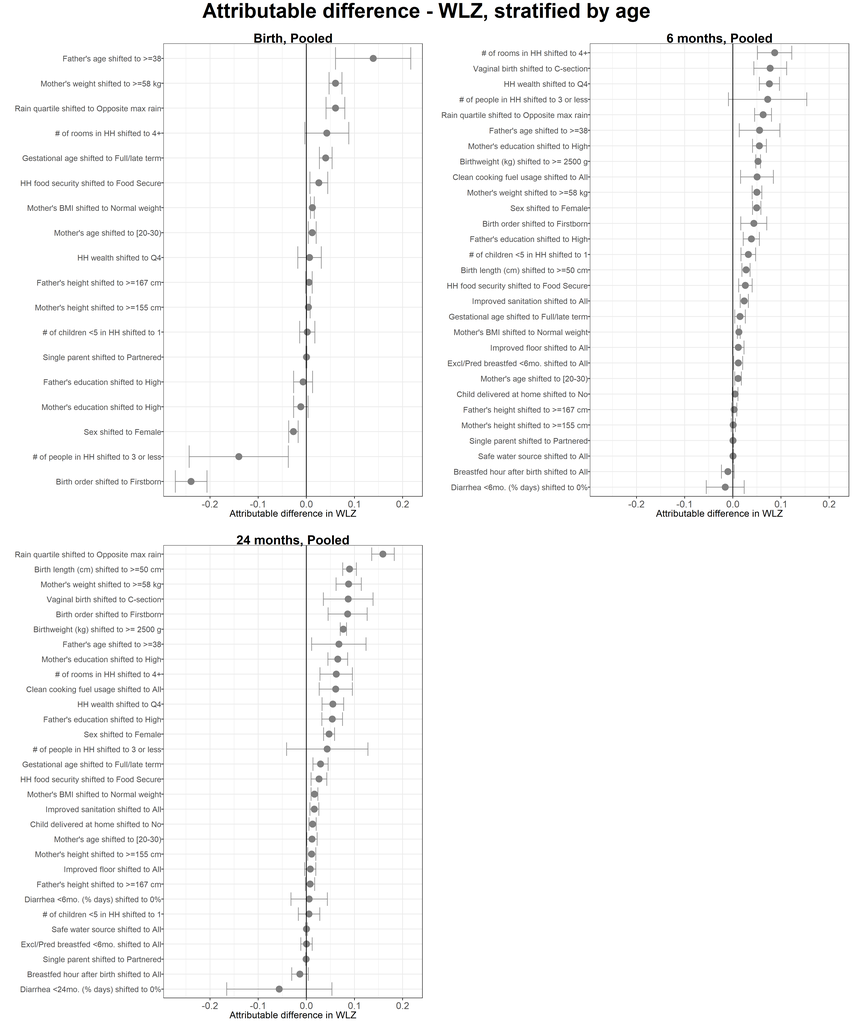

**Extended Data Figure 4 | Age-stratified population attributable differences in weight-for-length Z-scores estimated using fixed effects.**

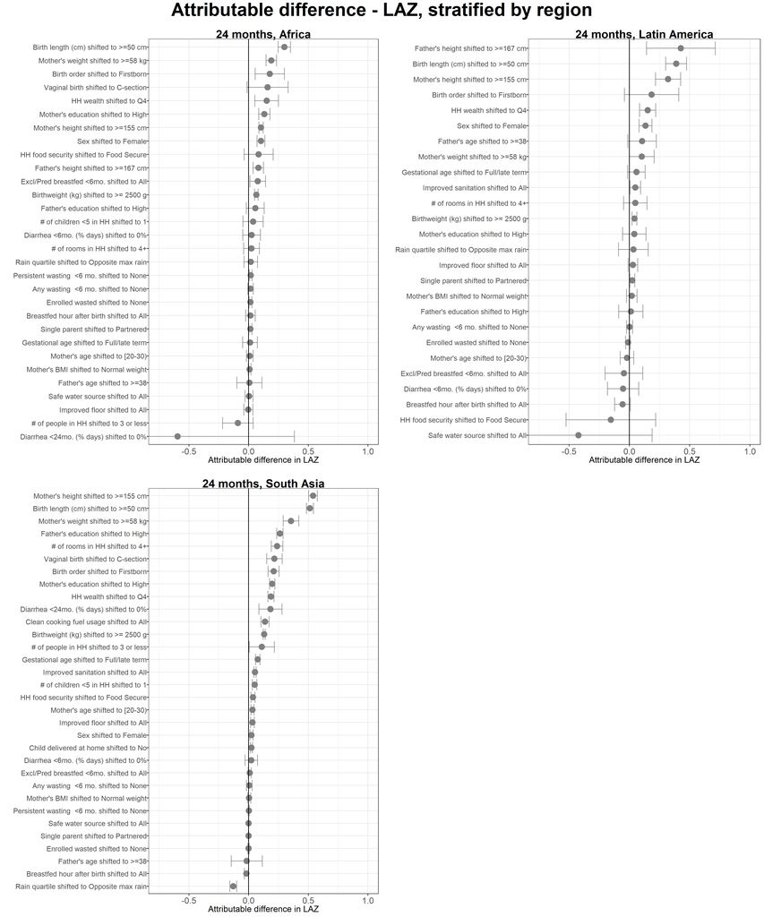

**Extended Data Figure 7 | Region-stratified population attributable differences in length-for-age Z-scores estimated using fixed effects.**

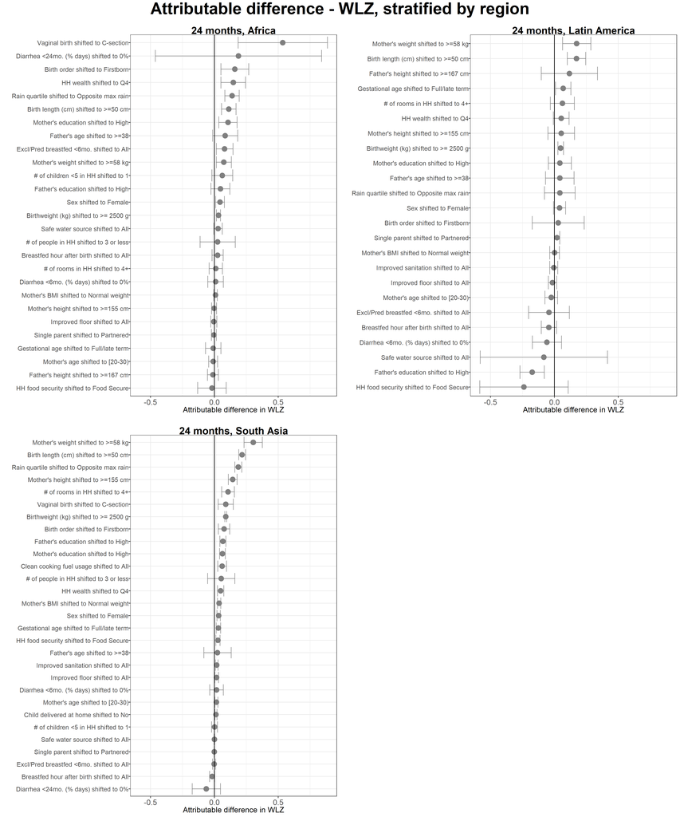

**Extended Data Figure 8 | Region-stratified population attributable differences in weight-for-length Z-scores estimated using fixed effects.**